# Part I - Ford GoBike Dataset Exploration

## by Johnpaul Kosisochukwu Nwagwu

## Introduction

> The Ford GoBike Dataset contains approximately 183,000 entries of individual rides made in a bike sharing system in Greater SanFrancisco Bay area. In this Project, we will start with univariate analysis, then bivariate analysis and finally, multivariate analysis. We will explore the data as we go and dig more deeply into relationships between variables than we may find interesting

## Preliminary Wrangling

```python
# import all packages and set plots to be embedded inline
import numpy as np
import pandas as pd
import matplotlib.pyplot as plt
import seaborn as sb

%matplotlib inline
```

```python
#Load dataset into pandas dataframe
gobike = pd.read_csv('201902-fordgobike-tripdata.csv')
```

```python
#print data shape, data types and composition
print(gobike.shape)
print(gobike.dtypes)
print(gobike.head())
```

```
(183412, 16)
duration_sec                 int64
start_time                  object
end_time                    object
start_station_id           float64
start_station_name          object
start_station_latitude     float64
start_station_longitude    float64
end_station_id             float64
end_station_name            object
end_station_latitude       float64
end_station_longitude      float64
bike_id                      int64
user_type                   object
member_birth_year          float64
member_gender               object
bike_share_for_all_trip     object
dtype: object
   duration_sec                start_time                  end_time  \
0         52185  2019-02-28 17:32:10.1450  2019-03-01 08:01:55.9750
1         42521  2019-02-28 18:53:21.7890  2019-03-01 06:42:03.0560
2         61854  2019-02-28 12:13:13.2180  2019-03-01 05:24:08.1460
3         36490  2019-02-28 17:54:26.0100  2019-03-01 04:02:36.8420
4          1585  2019-02-28 23:54:18.5490  2019-03-01 00:20:44.0740

   start_station_id                                start_station_name  \
0              21.0  Montgomery St BART Station (Market St at 2nd St)
1              23.0                     The Embarcadero at Steuart St
2              86.0                           Market St at Dolores St
3             375.0                           Grove St at Masonic Ave
4               7.0                               Frank H Ogawa Plaza

   start_station_latitude  start_station_longitude  end_station_id  \
0               37.789625              -122.400811            13.0
1               37.791464              -122.391034            81.0
2               37.769305              -122.426826             3.0
3               37.774836              -122.446546            70.0
4               37.804562              -122.271738           222.0

                               end_station_name  end_station_latitude  \
0                Commercial St at Montgomery St             37.794231
1                            Berry St at 4th St             37.775880
2  Powell St BART Station (Market St at 4th St)             37.786375
3                        Central Ave at Fell St             37.773311
4                         10th Ave at E 15th St             37.792714

   end_station_longitude  bike_id   user_type  member_birth_year  \
0            -122.402923     4902    Customer             1984.0
1            -122.393170     2535    Customer                NaN
2            -122.404904     5905    Customer             1972.0
3            -122.444293     6638  Subscriber             1989.0
4            -122.248780     4898  Subscriber             1974.0

  member_gender bike_share_for_all_trip
0          Male                      No
1           NaN                      No
2          Male                      No
3         Other                      No
4          Male                     Yes
```

```python
#descriptive statistics of numeric variables
gobike.describe()
```

|  | duration_sec | start_station_id | start_station_latitude | start_station_longitude | end_station_id | end_station_latitude | end_station_longitude | bike_id | member_birth_year |
| --- | --- | --- | --- | --- | --- | --- | --- | --- | --- |
| count | 183412.000000 | 183215.000000 | 183412.000000 | 183412.000000 | 183215.000000 | 183412.000000 | 183412.000000 | 183412.000000 | 175147.000000 |
| mean | 726.078435 | 138.590427 | 37.771223 | -122.352664 | 136.249123 | 37.771427 | -122.352250 | 4472.906375 | 1984.806437 |
| std | 1794.389780 | 111.778864 | 0.099581 | 0.117097 | 111.515131 | 0.099490 | 0.116673 | 1664.383394 | 10.116689 |
| min | 61.000000 | 3.000000 | 37.317298 | -122.453704 | 3.000000 | 37.317298 | -122.453704 | 11.000000 | 1878.000000 |
| 25% | 325.000000 | 47.000000 | 37.770083 | -122.412408 | 44.000000 | 37.770407 | -122.411726 | 3777.000000 | 1980.000000 |
| 50% | 514.000000 | 104.000000 | 37.780760 | -122.398285 | 100.000000 | 37.781010 | -122.398279 | 4958.000000 | 1987.000000 |
| 75% | 796.000000 | 239.000000 | 37.797280 | -122.286533 | 235.000000 | 37.797320 | -122.288045 | 5502.000000 | 1992.000000 |
| max | 85444.000000 | 398.000000 | 37.880222 | -121.874119 | 398.000000 | 37.880222 | -121.874119 | 6645.000000 | 2001.000000 |

### What is the structure of your dataset?

> There are 183,412 individual rides in this dataset with 16 features(duration_sec, start_time, end_time, start_station_id, start_station_name, start_station_latitude, start_station_longitude, end_station_id, end_station_name, end_station_latitude, end_station_longitude, bike_id, user_type, member_birth_year, member_gender, bike_share_for_all_trip). Most variables are numeric in nature(int or float type) but the user_type, start station name, member gender, bike share for all trip and end station names are nominal data.

### What is/are the main feature(s) of interest in your dataset?

> I'm most interested in finding the best features that influence the trip start time and how long an individual trip is going take(duration_sec)

### What features in the dataset do you think will help support your investigation into your feature(s) of interest?

> I expect that factors such as usertype, startdayname, start time hour to have the most effects on the trip duration.

## Univariate Exploration

> Here we look at individual variables and how they are distributed

### Data Wrangling

```python
#Change start time to date time type and split to day, month and year columns
gobike['start_time'] = pd.to_datetime(gobike['start_time'])

gobike['start_day'] = gobike.start_time.dt.day
gobike['start_dayname'] = gobike.start_time.dt.day_name()
gobike['start_month'] = gobike.start_time.dt.month
gobike['start_year'] = gobike.start_time.dt.year
```

```python
order = ["Monday","Tuesday","Wednesday", "Thursday", "Friday", "Saturday", "Sunday"]
gobike['start_dayname'] = pd.Categorical(gobike['start_dayname'], categories=order, ordered=True)
```

```python
#Change end time to date time type and split to day, month and year columns
gobike['end_time'] = pd.to_datetime(gobike['end_time'])

gobike['end_day'] = gobike.end_time.dt.day
gobike['end_dayname'] = gobike.end_time.dt.day_name()
gobike['end_dayname'] = pd.Categorical(gobike['end_dayname'], categories=order, ordered=True)
gobike['end_month'] = gobike.end_time.dt.month
gobike['end_year'] = gobike.end_time.dt.year
```

### What are the distribution of start day, month and year columns?

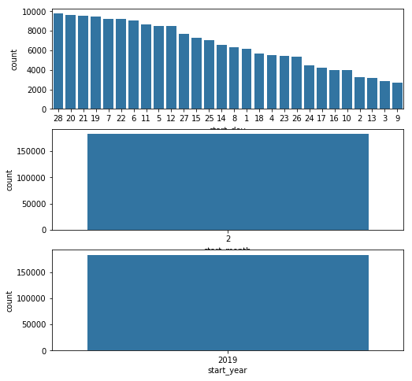

```python
#PLotting Start day, month and Year Distribution
default_color = sb.color_palette()[0]
userday_frequency = gobike['start_day'].value_counts()
userday_order = userday_frequency.index

usermonth_frequency = gobike['start_month'].value_counts()
usermonth_order = usermonth_frequency.index

useryear_frequency = gobike['start_year'].value_counts()
useryear_order = useryear_frequency.index

fig, ax = plt.subplots(nrows=3, figsize = [8,8])
sb.countplot(data = gobike, x = 'start_day', color = default_color, order=userday_order, ax=ax[0])
sb.countplot(data = gobike, x = 'start_month', color = default_color, order=usermonth_order, ax=ax[1])
sb.countplot(data = gobike, x = 'start_year', color = default_color, order=useryear_order, ax=ax[2])
plt.show()
```

The data collected for individual trips around the Sanfrancisco Bay Area seems to be for the month of February in the Year 2019. Looking how much trips were made for each day in the month of February, we see that there is no particular order or trend in terms of trip numbers increasing as the day number increases. The top 5 most travelled day suggests 28, 20, 21, 19 and 7. Perhaps, it will be worth looking at this data in terms of day names not day numbers to gain more useful insights.

### Can the Start day name column give us more useful insights? Let's find out

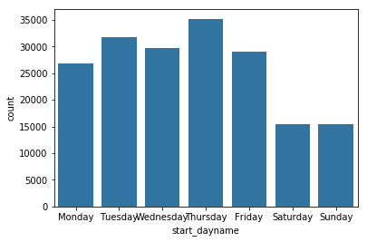

```python
#Looking at start day names
sb.countplot(data = gobike, x = 'start_dayname', color = default_color)
```

Here, we see that most individual trip in the Sanfrancisco bay Area were made on a Thursday in February 2019. The trip number was significantly reduced during weekends Saturday and Sunday. This could perhaps be because most individual trips were work trips. This is worth exploring

### What is the distribution of the End day, month and Year columns?

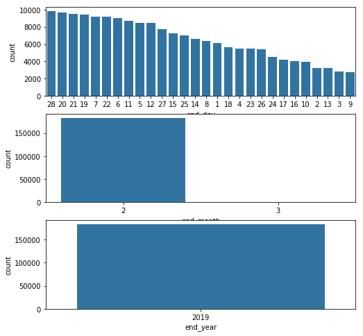

```python
#Plotting end day, month and Year Distributions
userday_frequency = gobike['end_day'].value_counts()
userday_order = userday_frequency.index

usermonth_frequency = gobike['end_month'].value_counts()
usermonth_order = usermonth_frequency.index

useryear_frequency = gobike['end_year'].value_counts()
useryear_order = useryear_frequency.index

fig, ax = plt.subplots(nrows=3, figsize = [8,8])
sb.countplot(data = gobike, x = 'end_day', color = default_color, order=userday_order, ax=ax[0])
sb.countplot(data = gobike, x = 'end_month', color = default_color, order=usermonth_order, ax=ax[1])
sb.countplot(data = gobike, x = 'end_year', color = default_color, order=useryear_order, ax=ax[2])
plt.show()
```

From our plots of the distribution of end of trip days, months and years. We notice that for the end months graph, it is shifted to the left signifying outliers in our data. The graph suggests that some individual trips were completed in the Month of March. My best guess is that it could be mostly trips that started on the last day of February. This is worth keeping in mind as we continue our analysis. It might come in handy. For the End Year graph, it shows that all trips were made in Year 2019. Our top 5 trip end days are 28,20, 21, 19 and 7 corresponding with our top 5 trip start days meaning that most trips ended on the same day. Perhaps, more short trips are common in our data.

Let's look at trip end day names distribution as we did for trip start days

```python
#Looking at a table of month 3 trips
gobike.query('end_month == 3')
```

|  | duration_sec | start_time | end_time | start_station_id | start_station_name | start_station_latitude | start_station_longitude | end_station_id | end_station_name | end_station_latitude | ... | member_gender | bike_share_for_all_trip | start_day | start_dayname | start_month | start_year | end_day | end_dayname | end_month | end_year |
| --- | --- | --- | --- | --- | --- | --- | --- | --- | --- | --- | --- | --- | --- | --- | --- | --- | --- | --- | --- | --- | --- |
| 0 | 52185 | 2019-02-28 17:32:10.145 | 2019-03-01 08:01:55.975 | 21.0 | Montgomery St BART Station (Market St at 2nd St) | 37.789625 | -122.400811 | 13.0 | Commercial St at Montgomery St | 37.794231 | ... | Male | No | 28 | Thursday | 2 | 2019 | 1 | Friday | 3 | 2019 |
| 1 | 42521 | 2019-02-28 18:53:21.789 | 2019-03-01 06:42:03.056 | 23.0 | The Embarcadero at Steuart St | 37.791464 | -122.391034 | 81.0 | Berry St at 4th St | 37.775880 | ... | NaN | No | 28 | Thursday | 2 | 2019 | 1 | Friday | 3 | 2019 |
| 2 | 61854 | 2019-02-28 12:13:13.218 | 2019-03-01 05:24:08.146 | 86.0 | Market St at Dolores St | 37.769305 | -122.426826 | 3.0 | Powell St BART Station (Market St at 4th St) | 37.786375 | ... | Male | No | 28 | Thursday | 2 | 2019 | 1 | Friday | 3 | 2019 |
| 3 | 36490 | 2019-02-28 17:54:26.010 | 2019-03-01 04:02:36.842 | 375.0 | Grove St at Masonic Ave | 37.774836 | -122.446546 | 70.0 | Central Ave at Fell St | 37.773311 | ... | Other | No | 28 | Thursday | 2 | 2019 | 1 | Friday | 3 | 2019 |
| 4 | 1585 | 2019-02-28 23:54:18.549 | 2019-03-01 00:20:44.074 | 7.0 | Frank H Ogawa Plaza | 37.804562 | -122.271738 | 222.0 | 10th Ave at E 15th St | 37.792714 | ... | Male | Yes | 28 | Thursday | 2 | 2019 | 1 | Friday | 3 | 2019 |
| 5 | 1793 | 2019-02-28 23:49:58.632 | 2019-03-01 00:19:51.760 | 93.0 | 4th St at Mission Bay Blvd S | 37.770407 | -122.391198 | 323.0 | Broadway at Kearny | 37.798014 | ... | Male | No | 28 | Thursday | 2 | 2019 | 1 | Friday | 3 | 2019 |
| 6 | 1147 | 2019-02-28 23:55:35.104 | 2019-03-01 00:14:42.588 | 300.0 | Palm St at Willow St | 37.317298 | -121.884995 | 312.0 | San Jose Diridon Station | 37.329732 | ... | Female | No | 28 | Thursday | 2 | 2019 | 1 | Friday | 3 | 2019 |
| 7 | 1615 | 2019-02-28 23:41:06.766 | 2019-03-01 00:08:02.756 | 10.0 | Washington St at Kearny St | 37.795393 | -122.404770 | 127.0 | Valencia St at 21st St | 37.756708 | ... | Male | No | 28 | Thursday | 2 | 2019 | 1 | Friday | 3 | 2019 |
| 8 | 1570 | 2019-02-28 23:41:48.790 | 2019-03-01 00:07:59.715 | 10.0 | Washington St at Kearny St | 37.795393 | -122.404770 | 127.0 | Valencia St at 21st St | 37.756708 | ... | Other | No | 28 | Thursday | 2 | 2019 | 1 | Friday | 3 | 2019 |
| 9 | 1049 | 2019-02-28 23:49:47.699 | 2019-03-01 00:07:17.025 | 19.0 | Post St at Kearny St | 37.788975 | -122.403452 | 121.0 | Mission Playground | 37.759210 | ... | Male | No | 28 | Thursday | 2 | 2019 | 1 | Friday | 3 | 2019 |
| 10 | 458 | 2019-02-28 23:57:57.211 | 2019-03-01 00:05:35.435 | 370.0 | Jones St at Post St | 37.787327 | -122.413278 | 43.0 | San Francisco Public Library (Grove St at Hyde... | 37.778768 | ... | Female | Yes | 28 | Thursday | 2 | 2019 | 1 | Friday | 3 | 2019 |
| 11 | 506 | 2019-02-28 23:56:55.540 | 2019-03-01 00:05:21.733 | 44.0 | Civic Center/UN Plaza BART Station (Market St ... | 37.781074 | -122.411738 | 343.0 | Bryant St at 2nd St | 37.783172 | ... | Male | No | 28 | Thursday | 2 | 2019 | 1 | Friday | 3 | 2019 |
| 12 | 1176 | 2019-02-28 23:45:12.651 | 2019-03-01 00:04:49.184 | 127.0 | Valencia St at 21st St | 37.756708 | -122.421025 | 323.0 | Broadway at Kearny | 37.798014 | ... | Male | No | 28 | Thursday | 2 | 2019 | 1 | Friday | 3 | 2019 |
| 13 | 915 | 2019-02-28 23:49:06.062 | 2019-03-01 00:04:21.867 | 252.0 | Channing Way at Shattuck Ave | 37.865847 | -122.267443 | 244.0 | Shattuck Ave at Hearst Ave | 37.873676 | ... | NaN | No | 28 | Thursday | 2 | 2019 | 1 | Friday | 3 | 2019 |
| 14 | 395 | 2019-02-28 23:56:26.848 | 2019-03-01 00:03:01.947 | 243.0 | Bancroft Way at College Ave | 37.869360 | -122.254337 | 252.0 | Channing Way at Shattuck Ave | 37.865847 | ... | Male | No | 28 | Thursday | 2 | 2019 | 1 | Friday | 3 | 2019 |
| 15 | 208 | 2019-02-28 23:59:18.548 | 2019-03-01 00:02:47.228 | 349.0 | Howard St at Mary St | 37.781010 | -122.405666 | 60.0 | 8th St at Ringold St | 37.774520 | ... | Male | Yes | 28 | Thursday | 2 | 2019 | 1 | Friday | 3 | 2019 |

16 rows × 24 columns

Digging more deeply, we see that the trips ended on 1st march and these trips started on 28 February 2019

### What do we expect the distribution of the End day name Column to look like? Do we expect it to be similar to the start day name column?

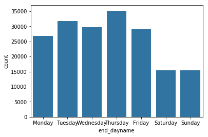

```python
#Looking at trip end day names
userdayname_frequency = gobike['end_dayname'].value_counts()
userdayname_order = userdayname_frequency.index
sb.countplot(data = gobike, x = 'end_dayname', color = default_color)
```

This has the same distribution as the trip start day names with the most trips ending on Thursdays and the least trips happening on Weekends Saturday and Sunday. This could mean that most individual gobike trips start and ends on the same day and they are short trips(less than 24 hrs)

### How are the Trip Lengths Distributed?

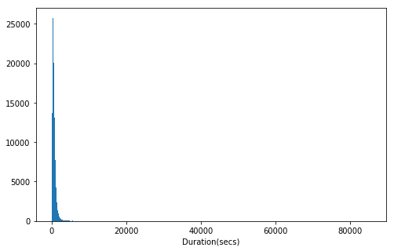

```python
# Looking at duration second column distribution
binsize = 100
bins = np.arange(0, gobike['duration_sec'].max()+binsize, binsize)

plt.figure(figsize=[8, 5])
plt.hist(data = gobike, x = 'duration_sec', bins = bins)
plt.xlabel('Duration(secs)')
plt.show()
```

From our graph above, it tells us that outliers exist in our data. The graph is shifted to the left meaning that there exists trip durations that are extremely long(> 40,000 seconds). Let us zoom into the graph a little bit to gain more insight

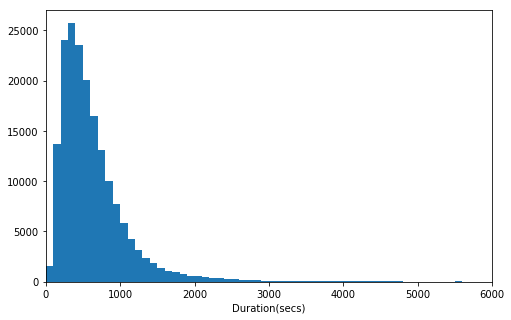

```python
binsize = 100
bins = np.arange(0, gobike['duration_sec'].max()+binsize, binsize)

plt.figure(figsize=[8, 5])
plt.hist(data = gobike, x = 'duration_sec', bins = bins)
plt.xlabel('Duration(secs)')
plt.xlim([0,6000])
plt.show()
```

Now we can see that the distribution is right skewed. We can also see that after about 5000 seconds, there are little or no counts for the remaining duration and we can exclude these seconds from our analysis. Let us zoom in a little bit more into our graph to get a shorter range of where our max value lies

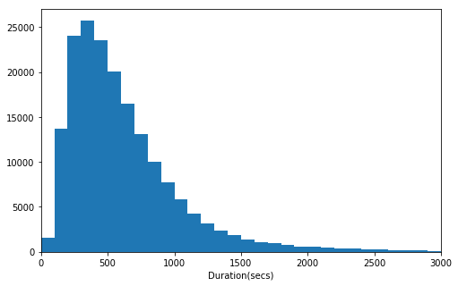

```python
binsize = 100
bins = np.arange(0, gobike['duration_sec'].max()+binsize, binsize)

plt.figure(figsize=[8, 5])
plt.hist(data = gobike, x = 'duration_sec', bins = bins)
plt.xlabel('Duration(secs)')
plt.xlim([0,3000])
plt.show()
```

```python
#looking at a table of trip duration greater than 8000 seconds
gobike.query('duration_sec > 80000')
```

|  | duration_sec | start_time | end_time | start_station_id | start_station_name | start_station_latitude | start_station_longitude | end_station_id | end_station_name | end_station_latitude | ... | member_gender | bike_share_for_all_trip | start_day | start_dayname | start_month | start_year | end_day | end_dayname | end_month | end_year |
| --- | --- | --- | --- | --- | --- | --- | --- | --- | --- | --- | --- | --- | --- | --- | --- | --- | --- | --- | --- | --- | --- |
| 5203 | 83195 | 2019-02-27 14:47:23.181 | 2019-02-28 13:53:58.433 | 243.0 | Bancroft Way at College Ave | 37.869360 | -122.254337 | 248.0 | Telegraph Ave at Ashby Ave | 37.855956 | ... | Female | Yes | 27 | Wednesday | 2 | 2019 | 28 | Thursday | 2 | 2019 |
| 8631 | 81549 | 2019-02-27 09:41:38.552 | 2019-02-28 08:20:48.386 | 138.0 | Jersey St at Church St | 37.750900 | -122.427411 | 140.0 | Cesar Chavez St at Dolores St | 37.747858 | ... | Female | No | 27 | Wednesday | 2 | 2019 | 28 | Thursday | 2 | 2019 |
| 85465 | 84548 | 2019-02-16 15:48:25.029 | 2019-02-17 15:17:33.080 | 3.0 | Powell St BART Station (Market St at 4th St) | 37.786375 | -122.404904 | 368.0 | Myrtle St at Polk St | 37.785434 | ... | Male | No | 16 | Saturday | 2 | 2019 | 17 | Sunday | 2 | 2019 |
| 95750 | 82512 | 2019-02-14 13:56:21.728 | 2019-02-15 12:51:34.315 | 368.0 | Myrtle St at Polk St | 37.785434 | -122.419622 | 44.0 | Civic Center/UN Plaza BART Station (Market St ... | 37.781074 | ... | Other | No | 14 | Thursday | 2 | 2019 | 15 | Friday | 2 | 2019 |
| 101361 | 85444 | 2019-02-13 17:59:55.124 | 2019-02-14 17:43:59.954 | 5.0 | Powell St BART Station (Market St at 5th St) | 37.783899 | -122.408445 | 98.0 | Valencia St at 16th St | 37.765052 | ... | NaN | No | 13 | Wednesday | 2 | 2019 | 14 | Thursday | 2 | 2019 |
| 112435 | 83407 | 2019-02-11 16:25:33.069 | 2019-02-12 15:35:40.956 | 77.0 | 11th St at Natoma St | 37.773507 | -122.416040 | 344.0 | 16th St Depot | 37.766349 | ... | Male | No | 11 | Monday | 2 | 2019 | 12 | Tuesday | 2 | 2019 |
| 127999 | 83519 | 2019-02-09 15:16:17.537 | 2019-02-10 14:28:17.270 | 72.0 | Page St at Scott St | 37.772406 | -122.435650 | 43.0 | San Francisco Public Library (Grove St at Hyde... | 37.778768 | ... | Male | No | 9 | Saturday | 2 | 2019 | 10 | Sunday | 2 | 2019 |
| 153705 | 83772 | 2019-02-05 12:44:54.286 | 2019-02-06 12:01:06.631 | 78.0 | Folsom St at 9th St | 37.773717 | -122.411647 | 345.0 | Hubbell St at 16th St | 37.766483 | ... | NaN | No | 5 | Tuesday | 2 | 2019 | 6 | Wednesday | 2 | 2019 |
| 173365 | 82385 | 2019-02-02 13:07:43.036 | 2019-02-03 12:00:48.175 | 377.0 | Fell St at Stanyan St | 37.771917 | -122.453704 | 377.0 | Fell St at Stanyan St | 37.771917 | ... | NaN | No | 2 | Saturday | 2 | 2019 | 3 | Sunday | 2 | 2019 |
| 176987 | 80891 | 2019-02-01 11:05:18.976 | 2019-02-02 09:33:30.169 | 44.0 | Civic Center/UN Plaza BART Station (Market St ... | 37.781074 | -122.411738 | 55.0 | Webster St at Grove St | 37.777053 | ... | NaN | No | 1 | Friday | 2 | 2019 | 2 | Saturday | 2 | 2019 |

10 rows × 24 columns

Nothing striking comes from this table, This is work looking into in future. Perhaps breaking our duration trip into 3 categories of short, medium and long trips.

### What is the composition of the types of gobike trip users?

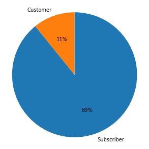

```python
#Next, Let us look at the user type distribution
plt.figure(figsize=[8, 5])
default_color = sb.color_palette()[0]
user_frequency = gobike['user_type'].value_counts()
user_order = user_frequency.index
plt.pie(user_frequency, labels=user_order, autopct='%1.0f%%', startangle = 90, counterclock = False)
plt.axis('square');
```

We see that majority of our users in the data are subscribers(old users who are frequently using the service) comprising of more than 80% of our data. Next, let us look the trip start and end times.

### What is the distribution of Trip hours? Do we see any pattern?

```python
#extracting trip start time and end time hours
gobike['start_hour'] = gobike['start_time'].dt.hour
gobike['end_hour'] = gobike['end_time'].dt.hour
```

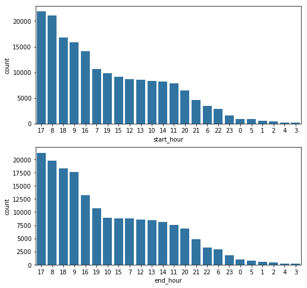

```python
#Plotting their distributions
starthour_frequency = gobike['start_hour'].value_counts()
starthour_order = starthour_frequency.index

endhour_frequency = gobike['end_hour'].value_counts()
endhour_order = endhour_frequency.index

fig, ax = plt.subplots(nrows=2, figsize = [8,8])
sb.countplot(data = gobike, x = 'start_hour', color = default_color, order=starthour_order, ax=ax[0])
sb.countplot(data = gobike, x = 'end_hour', color = default_color, order=endhour_order, ax=ax[1])
plt.show()
```

The individual start trip hours and the Individual End trip hours look similar in values and pattern. The top 5 most travelled start hours are 17:00,8:00,18:00,9:00,16:00 hours which correspond with the end time hours. Their similar values tells us that most of the individual trips are less than an hour in time and the values suggest that most gobike users in Sanfranciso bay in February 2019 use goride for work rides. This also suggests that Aside work travel hours, afternoon trips are more common, followed by late night trips and then early morning trips

### How much gobike trips are shared?

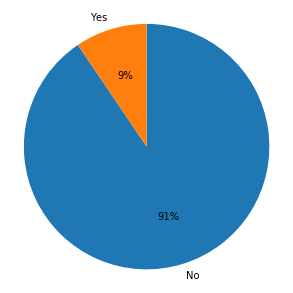

```python
#Distribution of Bike share for all trip
plt.figure(figsize=[8, 5])
default_color = sb.color_palette()[0]
user_frequency = gobike['bike_share_for_all_trip'].value_counts()
user_order = user_frequency.index
plt.pie(user_frequency, labels=user_order, autopct='%1.0f%%', startangle = 90, counterclock = False)
plt.axis('square');
```

This tells us that most bike trips were not shared with only less than 10% being shared trips. It is worth looking into trips that were shared for perhaps any insights.

### What is the distribution of user gender in our data? Is any gender dominant?

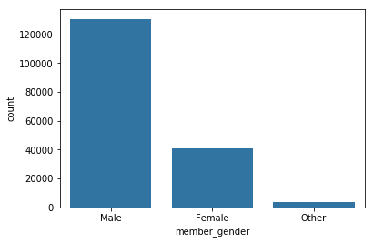

```python
#Looking at member gender distribution
genderfrequency = gobike['member_gender'].value_counts()
gender_order = genderfrequency.index
sb.countplot(data = gobike, x = 'member_gender', color = default_color, order=gender_order)
plt.show()
```

This graph above tells us that most gobike users in Francisco Bay Area in the Year 2019 and month of Febraury are Males being more than twice as large as females

### How about the member birth year distribution? any outliers?

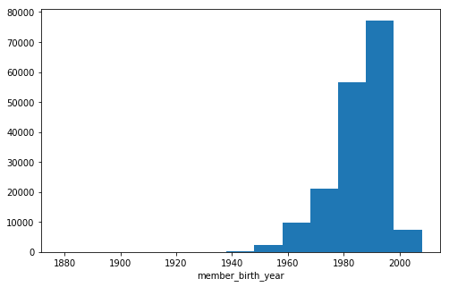

```python
#member birth year distribution
binsize = 10
gobike['member_birth_year'].dropna(inplace=True)
bins = np.arange(gobike['member_birth_year'].min(), gobike['member_birth_year'].max()+binsize, binsize)

plt.figure(figsize=[8, 5])
plt.hist(data = gobike, x = 'member_birth_year', bins = bins)
plt.xlabel('member_birth_year')
#plt.xlim([0,3000])
plt.show()
```

The plot of the member birth year distribution tells us that there is an outlier as the graph is shifted to the right. Let us zoom in to the graph to gain more insights

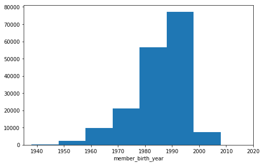

```python
#member birth year distribution
binsize = 10
gobike['member_birth_year'].dropna(inplace=True)
bins = np.arange(gobike['member_birth_year'].min(), gobike['member_birth_year'].max()+binsize, binsize)

plt.figure(figsize=[8, 5])
plt.hist(data = gobike, x = 'member_birth_year', bins = bins)
plt.xlabel('member_birth_year')
plt.xlim([1935,2020])
plt.show()
```

Removing the outlier, we can see that the graph is clearer. The most frequent member birth dates are between about 1980 and 2000. Looking at the age distribution, It suggests users between the ages of 39 and 19 years.

### Are there common top station Ids for Trips?

```python
#changing datatype and filling missing values of start station id and end station id with 0
gobike['start_station_id'] = gobike['start_station_id'].fillna(0.0).astype('int')
gobike['end_station_id'] = gobike['end_station_id'].fillna(0.0).astype('int')
```

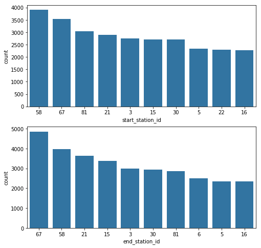

```python
#Plotting start id distributions
startid_frequency = gobike['start_station_id'].value_counts().nlargest(10)
startid_order = startid_frequency.index

endid_frequency = gobike['end_station_id'].value_counts().nlargest(10)
endid_order = endid_frequency.index

fig, ax = plt.subplots(nrows=2, figsize = [8,8])
sb.countplot(data = gobike, x = 'start_station_id', color = default_color, order=startid_order, ax=ax[0])
sb.countplot(data = gobike, x = 'end_station_id', color = default_color, order=endid_order, ax=ax[1])
plt.show()
```

### What are the least visited station Ids?

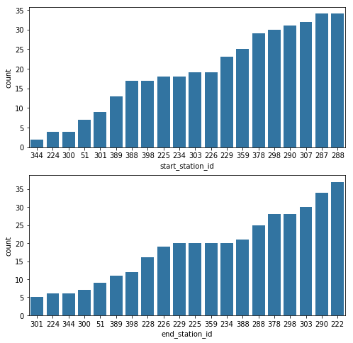

```python
#Plotting start id distributions
startid_frequency = gobike['start_station_id'].value_counts().nsmallest(20)
startid_order = startid_frequency.index

endid_frequency = gobike['end_station_id'].value_counts().nsmallest(20)
endid_order = endid_frequency.index

fig, ax = plt.subplots(nrows=2, figsize = [8,8])
sb.countplot(data = gobike, x = 'start_station_id', color = default_color, order=startid_order, ax=ax[0])
sb.countplot(data = gobike, x = 'end_station_id', color = default_color, order=endid_order, ax=ax[1])
plt.show()
```

### Discuss the distribution(s) of your variable(s) of interest. Were there any unusual points? Did you need to perform any transformations?

> The distribution of the duration variable is right skewed. There are unsual points of travelled time duration of up to 80,000 seconds. But these instances were few as compared to the distribution of most of the duration time.

### Of the features you investigated, were there any unusual distributions? Did you perform any operations on the data to tidy, adjust, or change the form of the data? If so, why did you do this?

> I was interested in looking at the start time and end time columns so I made the following transformation

```
Change start time to date time type and split to day, dayname, month and year columns
Change end time to date time type and split to day, dayname, month and year columns
```

Also, some trips ended in the month of march while all trips started in February

The member bith year had an outlier of about 1880 so I choose birth years of 1935 to 2020 which appears more reasonable from the graph

## Bivariate Exploration

> In this section, we will investigate relationships between two variables

### Are there any strong correlations between our numeric quantities of interest?

```python
#First, let us start by putting our variables of interest into a list
numeric_vars = ['duration_sec','start_hour','end_hour']
categoric_vars = ['user_type', 'member_gender', 'bike_share_for_all_trip', 'start_dayname','end_dayname']
```

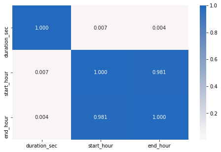

```python
# correlation plot between numeric variables
plt.figure(figsize = [8, 5])
sb.heatmap(gobike[numeric_vars].corr(), annot = True, fmt = '.3f',
           cmap = 'vlag_r', center = 0)
plt.show()
```

We see that there is a strong correlation between start hours and end hours

### Are there Linear Relationships between our numeric quantities? What is the strength and direction if any?

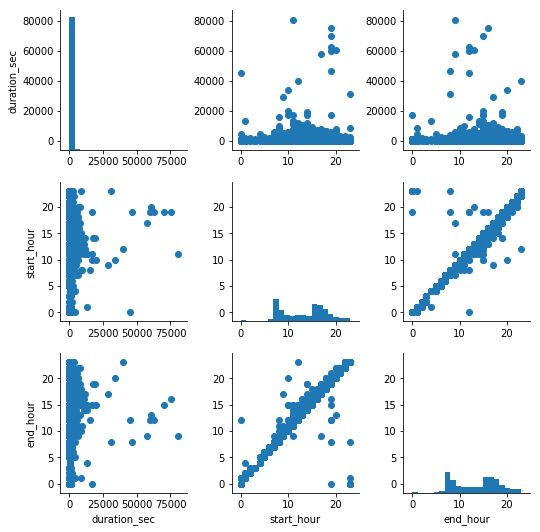

```python
# plot matrix: sample 500 gobike individual rides so that plots are clearer and
# they render faster
samples = np.random.choice(gobike.shape[0], 10000, replace = False)
gobike_samp = gobike.loc[samples,:]

g = sb.PairGrid(data = gobike_samp, vars = numeric_vars)
g = g.map_diag(plt.hist, bins = 20);
g.map_offdiag(plt.scatter)
```

### compare numeric variables to categoric variables

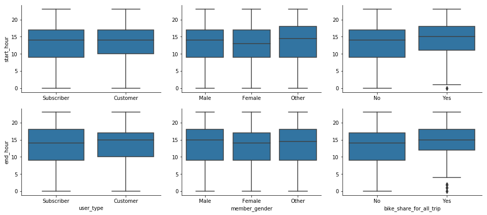

```python
#next we will compare numeric variables to categoric variables

samples = np.random.choice(gobike.shape[0], 10000, replace = False)
gobike_samp = gobike.loc[samples,:]

def boxgrid(x, y, **kwargs):
    """ Quick hack for creating box plots with seaborn's PairGrid. """
    default_color = sb.color_palette()[0]
    sb.boxplot(x, y, color = default_color)

plt.figure(figsize = [10, 10])
g = sb.PairGrid(data = gobike_samp, y_vars = ['start_hour','end_hour'], x_vars = ['user_type', 'member_gender', 'bike_share_for_all_trip'],
                size = 3, aspect = 1.5)
g.map(boxgrid)
plt.show();
```

Interestingly, Despite the number of subscribers being more than double the size of customers as seen previously, they boast similar start hours on average as compared with the Subscribers but they have thinner interquartile range for the end hours.

For the Gender of individuals on gobike data, we see than the male and female have about the same mean value for start and end hours desquite the frequency of males being more than half of the females in the data(gender imbalance).

Finally, as expected the box plots for both the end hours and start hours of the bike share trip for all trip are the same since they are for the same trip

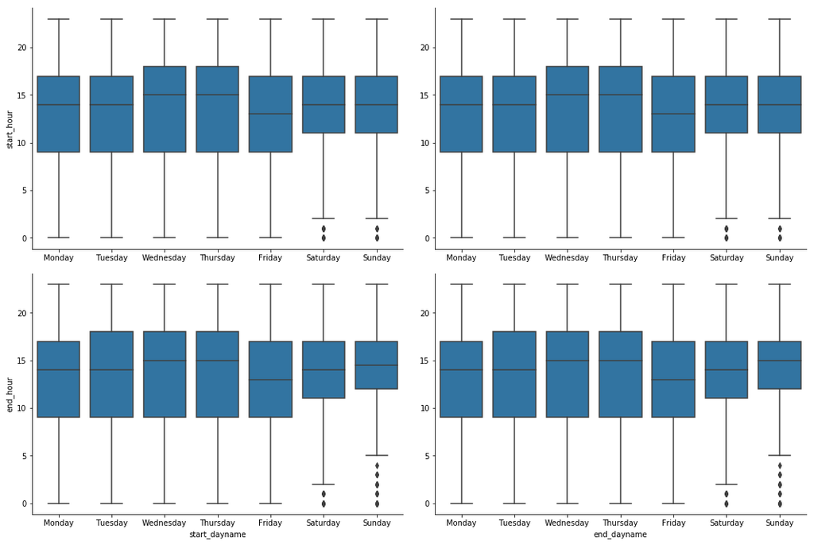

```python
#comparing numeric to categorical variable continues
g = sb.PairGrid(data = gobike_samp, y_vars = ['start_hour','end_hour'], x_vars = ['start_dayname','end_dayname'],
                size = 5, aspect = 1.5)
g.map(boxgrid)
plt.show();
```

Looking at the start day names and end day names distribution against start and end hours, we see that outliers are present on Saturdays and Sundays(midnight/very early morning trips). This tells us that most earling morning and late night trips were made on weekends

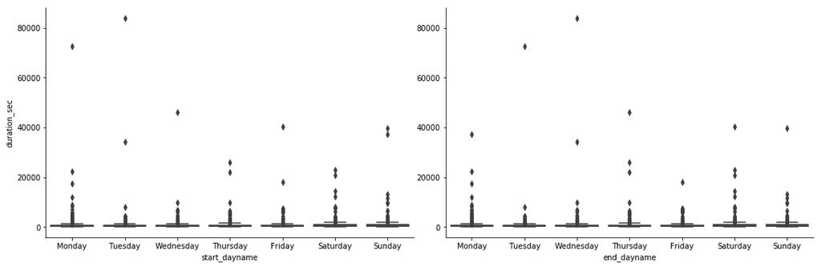

```python
#comparing numeric to categorical variable continues
g = sb.PairGrid(data = gobike_samp, y_vars = ['duration_sec'], x_vars = ['start_dayname','end_dayname'],
                size = 5, aspect = 1.5)
g.map(boxgrid)
plt.show();
```

Due to the presence of larger travel duration in our data, our boxplot does not show us the mean and interquartile range clearly but it does tell us that despite Saturdays and Sundays having odd travel hours as compared to the rest of the weekend, Almost every day of the week here contain odd values for travel duration that is there are long trips made on every day. Perhaps, this brings into mind, our initial thought of dividing duration into categories and further exploring. This we will see in our multivaruiate analysis

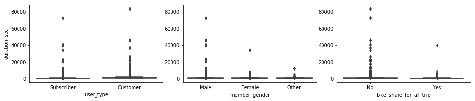

```python
#comparing numeric t6o categorical variable continues
g = sb.PairGrid(data = gobike_samp, y_vars = ['duration_sec'], x_vars = ['user_type', 'member_gender', 'bike_share_for_all_trip'],
                size = 3, aspect = 1.5)
g.map(boxgrid)
plt.show();
```

### compare categorical against categorical variables

There is no essential data to derive from here other than that outliers are also present in duration(travel time)

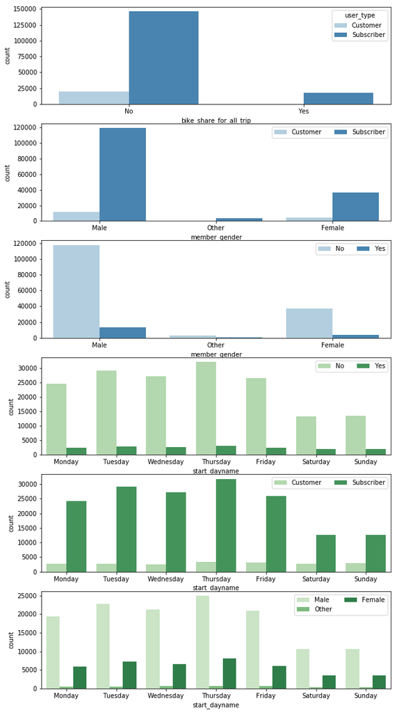

```python
# Next, we evaluate categorical vs categorical variables
plt.figure(figsize = [10, 20])

# subplot 1: bike_share_for_all_trip vs user_type
plt.subplot(6, 1, 1)
sb.countplot(data = gobike, x = 'bike_share_for_all_trip', hue = 'user_type', palette = 'Blues')

# subplot 2: member_gender vs. user_type
ax = plt.subplot(6, 1, 2)
sb.countplot(data = gobike, x = 'member_gender', hue = 'user_type', palette = 'Blues')
ax.legend(ncol = 2) # re-arrange legend to reduce overlapping

# subplot 3: member_gender vs. bike_share_for_all_trip,
ax = plt.subplot(6, 1, 3)
sb.countplot(data = gobike, x = 'member_gender', hue = 'bike_share_for_all_trip', palette = 'Blues')
ax.legend(loc = 1, ncol = 2) # re-arrange legend to remove overlapping

# subplot 3: start_dayname vs. bike_share_for_all_trip, use different color palette
ax = plt.subplot(6, 1, 4)
sb.countplot(data = gobike, x = 'start_dayname', hue = 'bike_share_for_all_trip', palette = 'Greens')
ax.legend(loc = 1, ncol = 2) # re-arrange legend to remove overlapping

# subplot 3: start_dayname vs. user_type, use different color palette
ax = plt.subplot(6, 1, 5)
sb.countplot(data = gobike, x = 'start_dayname', hue = 'user_type', palette = 'Greens')
ax.legend(loc = 1, ncol = 2) # re-arrange legend to remove overlapping

# subplot 3: start_dayname vs. member_gender, use different color palette
ax = plt.subplot(6, 1, 6)
sb.countplot(data = gobike, x = 'start_dayname', hue = 'member_gender', palette = 'Greens')
ax.legend(loc = 1, ncol = 2) # re-arrange legend to remove overlapping

plt.show()
```

Comparing crucial categorical varaibles against each other, we note the following findings

1) All shared trips are by Suscribers only

2) Users whose gender is other are all Subscribers

3) Most of the trips are individual trips and not shared

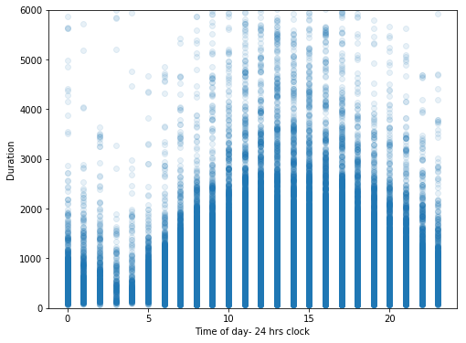

```python
# scatter plot of start hour vs duration
plt.figure(figsize = [8, 6])
plt.scatter(data = gobike, x = 'start_hour', y = 'duration_sec', alpha = 1/10)
plt.ylim([0, 6000])
plt.ylabel('Duration')
plt.xlabel('Time of day- 24 hrs clock')
plt.show()
```

Here, we see the general pattern between trip duration and time of the day is somewhat in 2 parts. However there are two parts to the trend, First on average the trip duration seems to increase from before 5:00 to somewhere after 15:00 where it changes course and starts decreasing on an average(ignoring outliers). The work travel hours seems to make the graph a bit difficult to interpret. Perhaps a good way to analyze the graph will be to consider different time of the day scenarios

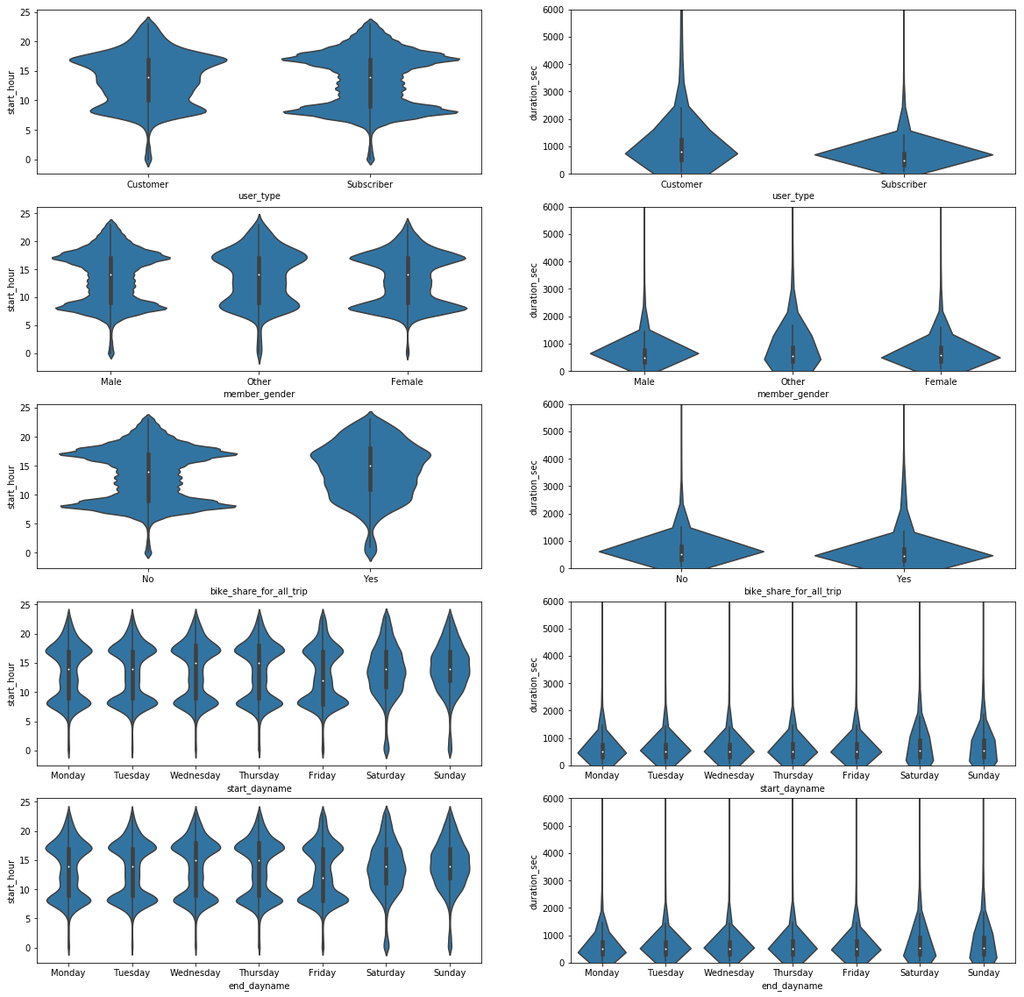

```python
#Next, I want to see how a violin plot looks like on some variables
# plot the categorical variables against start_hour and trip duration
fig, ax = plt.subplots(ncols = 2, nrows = 5 , figsize = [20,20])

for i in range(len(categoric_vars)):
    var = categoric_vars[i]
    sb.violinplot(data = gobike, x = var, y = 'start_hour', ax = ax[i,0],
               color = default_color)
    sb.violinplot(data = gobike, x = var, y = 'duration_sec', ax = ax[i,1],
               color = default_color)
    ax[i,1].set_ylim(np.array([0, 6000]))#limiting trip durating to 6000 seconds

plt.show()
```

I see nothing noteworthy that has not been previously discussed in the violin plots

### Did you observe any interesting relationships between the other features (not the main feature(s) of interest)?

> Interestingly, Despite the number of subscribers being more than double the size of customers as seen previously, they boast similar start hours on average as compared with the Subscribers but they have thinner interquartile range for the end hours. For the Gender of individuals on gobike data, we see than the male and female have about the same mean value for start and end hours despite the frequency of males being more than half of the females in the data(gender imbalance). Finally, as expected the box plots for both the end hours and start hours of the bike share trip for all trip are the same since they are for the same trip

> Looking at the start day names and end day names distribution against start and end hours, we see that outliers are present on Saturdays and Sundays(midnight/very early morning trips). This gives us an idea that early morning and late night trips perhaps are more common in weekends

> All shared trips are by Suscribers only

> Users whose gender is other are all Subscribers

> Most of the trips are individual trips and not shared

## Multivariate Exploration

> Here we want to look at how trip duration and start hours compare with some categories

### How does trip duration and start hours compare with trip hours, user types, and days?

```python
def hist2dgrid(x, y, **kwargs):
    """ Quick hack for creating heat maps with seaborn's PairGrid. """
    palette = kwargs.pop('color')
    plt.hist2d(x, y, cmap = palette, cmin = 0.5)
```

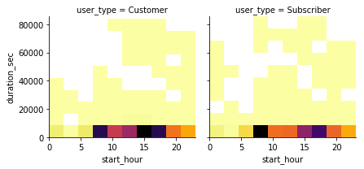

```python
# create faceted heat maps on levels of the start_hour variable
g = sb.FacetGrid(data = gobike, col = 'user_type', col_wrap = 3, size = 3)
g.map(hist2dgrid, 'start_hour', 'duration_sec', color = 'inferno_r')
plt.show()
```

As seen, mahjority of the points are concentrated beneath 2000 seconds trip duration and the peak start hours seems to be just before 10:00 and 15:00 hours. The other points suggest that on an average there is apositive correlation beneath trip duration and travel time although few outliers counter suggest idea. This is worth more indepth exploration. We can't necessarily draw any conclusion with this plots but the Subscriber graphs gives us a sense that 10:00 to 15:00 hours don't look as heavy in Subscribers than it does for Customers

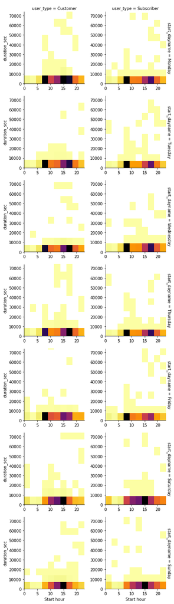

```python
# create faceted heat maps on levels of user_type and start_day name
g = sb.FacetGrid(data = gobike, col = 'user_type', row = 'start_dayname', size=3, margin_titles=True)
g.map(hist2dgrid, 'start_hour', 'duration_sec', color = 'inferno_r')
g.set_xlabels('Start hour')
g.set_ylabels('duration_sec')

plt.show()
```

We see the different trip duration for different start hours for different days. It is hard to draw a pattern from these graphs but one striking thing is that somewhere 15:00 hours and 10 hours is worth looking into for gobike users. Let's separate into various hours and explore

```python
# Next let us explore these hours a bit,  select trips duration less than 3000 and start hour greater than 6
gobike2 = (gobike['duration_sec'] <= 3000) & (gobike['start_hour'].between(4,21))
gobike21 = gobike.loc[gobike2,:]
```

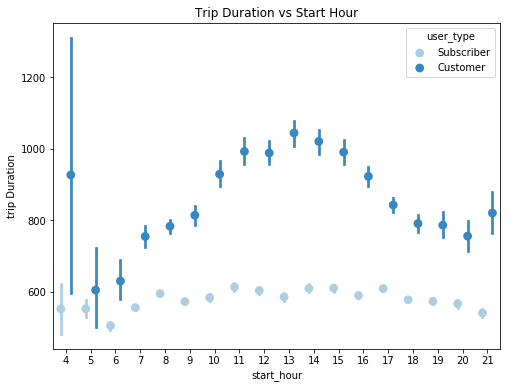

```python
fig = plt.figure(figsize = [8,6])
ax = sb.pointplot(data = gobike21, x = 'start_hour', y = 'duration_sec', hue = 'user_type',
           palette = 'Blues', linestyles = '', dodge = 0.4)
plt.title('Trip Duration vs Start Hour')
plt.ylabel('trip Duration')
ax.set_yticklabels([],minor = True)
plt.show();
```

Interesting insights, So in general for hours between 4:00 and 21:00, The Customers spend more time travelling than the subscribers with the peak travel time being between 11:00 and 15:00 of less than 1100 seconds. The Suscribers peak travel duration is almost constant at about 600 seconds

```python
# Next let us explore these hours a bit,  select trips duration more than 3000 and start hour between 0 and 4
gobike2 = (gobike['duration_sec'] >= 3000) & (gobike['start_hour'].between(0,4))
gobike21 = gobike.loc[gobike2,:]
```

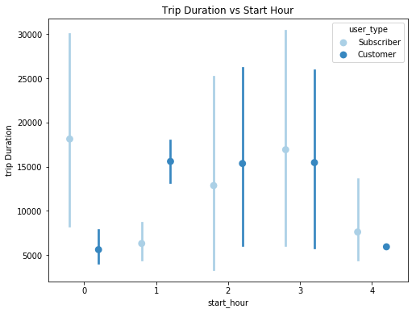

```python
fig = plt.figure(figsize = [8,6])
ax = sb.pointplot(data = gobike21, x = 'start_hour', y = 'duration_sec', hue = 'user_type',
           palette = 'Blues', linestyles = '', dodge = 0.4)
plt.title('Trip Duration vs Start Hour')
plt.ylabel('trip Duration')
ax.set_yticklabels([],minor = True)
plt.show();
```

```python
# Next let us explore these hours a bit,  select trips duration more than 3000 and start hour between 0 and 4
gobike2 = (gobike['duration_sec'] >= 3000) & (gobike['start_hour'].between(21,24))
gobike21 = gobike.loc[gobike2,:]
```

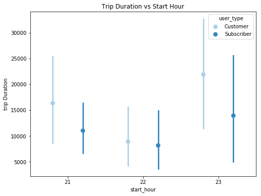

```python
fig = plt.figure(figsize = [8,6])
ax = sb.pointplot(data = gobike21, x = 'start_hour', y = 'duration_sec', hue = 'user_type',
           palette = 'Blues', linestyles = '', dodge = 0.4)
plt.title('Trip Duration vs Start Hour')
plt.ylabel('trip Duration')
ax.set_yticklabels([],minor = True)
plt.show();
```

### Talk about some of the relationships you observed in this part of the investigation. Were there features that strengthened each other in terms of looking at your feature(s) of interest?

> mahjority of the points are concentrated beneath 2000 seconds trip duration and the peak start hours seems to be just before 10:00 and 15:00 hours for the trip duration vs start hour plot. The other points suggest that on an average there is a positive correlation beneath trip duration and travel time although few outliers counter suggest idea. This is worth more indepth exploration. We can't necessarily draw any conclusion with this plots but the Subscriber graphs gives us a sense that 10:00 to 15:00 hours don't look as heavy in Subscribers than it does for Customers

### Were there any interesting or surprising interactions between features?

> Interesting insights, So in general for hours between 4:00 and 21:00, The Customers spend more time travelling than the subscribers with the peak travel time being between 11:00 and 15:00 of less than 1100 seconds. The Suscribers peak travel duration is almost constant at about 600 seconds

## Conclusions

#### Univariate Analysis

> Data collected was for the month of February and the year 2019.

> The top five most travelled days in February are 28th, 20th, 21st, 19th and 7th

> Most trips were made on thursdays with over 35000 trips with the least trips made on weekends(Saturdays and Sundays) of about 15,000

> Some trips started on 28th February and ended on March 1

> Trips of up to 80,000 seconds were recorded in a few instances

> Top 5 Most travelled times are 5pm, 8am, 6pm, 9am and 4pm.

> Aside work travel hours, afternoon trips are more common, followed by late night trips and then early morning trips

> Male users were more than twice as large as female users

> Outlier present in member birth year. Graph of memeber birth year is left skewed with the most frequent age bracket between 19 and 39 years

> Start stations id 58 and 67 wre the most visited stations.

> Most trips started in station ids 58, 67, 81, 21 and 3 and ended in station ids 67, 58, 21, 15 and 3

#### Bivariate Analysis

> As we suspected during our initial exploration, the start hours and end hours of trips in our data show a strong linear relationship with one another

> Interestingly, Despite the number of subscribers being more than double the size of customers as seen previously, they boast similar start hours on average as compared with the Subscribers but they have thinner interquartile range for the end hours.

> For the Gender of individuals on gobike data, we see than the male and female have about the same mean value for start and end hours desquite the frequency of males being more than half of the females in the data(gender imbalance).

> Finally, as expected the box plots for both the end hours and start hours of the bike share trip for all trip are the same since they are for the same trip

> Looking at the start day names and end day names distribution against start and end hours, we see that outliers are present on Saturdays and Sundays(midnight/very early morning trips). This gives us an idea that early morning and late night trips perhaps are more common in weekends

> All shared trips are by Suscribers only

> Users whose gender is other are all Subscribers

> Most of the trips are individual trips and not shared

#### Multivariate Analysis

> Interesting insights, So in general for hours between 4:00 and 21:00, The Customers spend more time travelling than the subscribers with the peak travel time being between 11:00 and 15:00 of less than 1100 seconds. The Suscribers peak travel duration is almost constant at about 600 seconds